# Practical Machine Learning Project

# Summary

Human Activity Recognition (HAR) are wearable devices that can be used to measure a range of variables of movement performed by the user. For this work, various users performed a range of activities while wearing sensors on the waist, upper arm, lower arm, waist and on a dumbell being used.

A data set of 19,622 entries is analysed for this work. Each entry corresponds to one of five activities which is specified in the data. The aim of this work is to train a machine learning model accurate enough to predict what type of activity a user is performing in a test data set of 20 entries where activity type is not specified.

# Importing and Cleaning Data

Initially, the 19,622 training cases and 20 test cases were loaded into R. The raw data describes 160 variables.

```r
training <- read.csv("pml-training.csv")
testing <- read.csv("pml-testing.csv")
```

The variable on which the data is modelled, classe, describes the type of activity being performed as A, B, C, D or E. As this work needs to predict which category of activity each entry corresponds to, it it appropriate to convert the classe variable to a categorical factor.

```r
## change class to factor
training$classe <- as.factor(training$classe)
```

The data set features a significant proportion of variables without an entry, or more specifically a string variable with one space, ie. " ". The entire data set was searched to find instances of these entries and where present, were changed to NA for further processing.

```r
library(dplyr)
test <- training[1,12]

training.mod <- training

## Convert empty entries to NA's

for(i in 1:nrow(training.mod)) {
        for(j in 1:ncol(training.mod)) {
                if(!is.na(training.mod[i,j])) {
                         if(training.mod[i,j] == test) {
                                training.mod[i,j] <- NA
                         }
                }
        }
}
```

In variables where empty values are present, and concurrently, NA entries, they appear to dominate. Among all the entries with NA values, NA’s were found in at least 97.9% of observations. For this reason, these variables were found to be redundant and were excluded from modelling.

```r
## Check proportion of NA's for a given variable

na.proportion <- colSums(is.na(training.mod))/nrow(training.mod)

na.proportion.positive <- na.proportion[na.proportion > 0]

no.nas <- na.proportion[na.proportion == 0]

keep <- names(no.nas)

trimmed <- training.mod %>%
        select(keep)
```

```
## Note: Using an external vector in selections is ambiguous.
## ℹ Use `all_of(keep)` instead of `keep` to silence this message.
## ℹ See <https://tidyselect.r-lib.org/reference/faq-external-vector.html>.
```

The first seven variables in the data set also relate to non-movement specific data and were deemed suitable for exclusion.

```r
## Exclude first 7 rows that have useless data
names(trimmed[,1:7])
```

```
## [1] "X"                    "user_name"            "raw_timestamp_part_1"
## [4] "raw_timestamp_part_2" "cvtd_timestamp"       "new_window"
## [7] "num_window"
```

```r
refined <- trimmed[,8:60]
```

The final, tidy data set included 53 variables down from 160. This includes 52 numerical variables relating to movement measurements, and one classe variable describing the type of movement being undertaken.

# Partitioning and Modelling the Data

The training data was partitioned into sub-groups based on a 90% prevalence for training and 10% for testing

```r
## split into training and testing sets
library(caret)
set.seed(123)
trainIndex <- createDataPartition(refined$classe, p = 0.9, list = FALSE)
sub.training <- refined[trainIndex,]
sub.testing <- refined[-trainIndex,]
```

In order to reduce the time to generate each model, parallel computing was used based on three parallel cores.

```r
library(parallel)
library(doParallel)
cores <- makeCluster(detectCores() - 1)
registerDoParallel(cores)
```

The initial modeling approach was to use a Classification and Regression Tree (CART) model with no cross-validation and no tuning.

```r
system.time(model <- train(classe~.,
                           data = sub.training,
                           method = "rpart"))
```

```
##    user  system elapsed
##   9.272   0.190  30.496
```

```r
predict.model <- predict(model, newdata = sub.testing)

confusionMatrix(sub.testing$classe, predict.model)
```

```
## Confusion Matrix and Statistics
##
##           Reference
## Prediction   A   B   C   D   E
##          A 500  10  47   0   1
##          B 170 127  82   0   0
##          C 156  11 175   0   0
##          D 146  49 126   0   0
##          E  57  41  91   0 171
##
## Overall Statistics
##
##                Accuracy : 0.4964
##                  95% CI : (0.4741, 0.5188)
##     No Information Rate : 0.525
##     P-Value [Acc > NIR] : 0.9947
##
##                   Kappa : 0.3414
##
##  Mcnemar's Test P-Value : NA
##
## Statistics by Class:
##
##                      Class: A Class: B Class: C Class: D Class: E
## Sensitivity            0.4859   0.5336  0.33589       NA  0.99419
## Specificity            0.9377   0.8537  0.88395   0.8362  0.89430
## Pos Pred Value         0.8961   0.3351  0.51170       NA  0.47500
## Neg Pred Value         0.6227   0.9298  0.78616       NA  0.99938
## Prevalence             0.5250   0.1214  0.26582   0.0000  0.08776
## Detection Rate         0.2551   0.0648  0.08929   0.0000  0.08724
## Detection Prevalence   0.2847   0.1934  0.17449   0.1638  0.18367
## Balanced Accuracy      0.7118   0.6936  0.60992       NA  0.94424
```

This initial model provides and overall accuracy of 49.6% percent. While this is better than guesswork (20%), development and refinement of the model yields more accurate results. The same model is implemented again, but with cross-validation included.

```r
ctrl <- trainControl(method = "repeatedcv",
                     number = 10,
                     allowParallel = TRUE)

system.time(model2 <- train(classe~.,
                           data = sub.training,
                           method = "rpart",
                           trControl = ctrl))
```

```
##    user  system elapsed
##   9.073   0.199  12.966
```

```r
predict.model2 <- predict(model2, newdata = sub.testing)

confusionMatrix(sub.testing$classe, predict.model2)
```

```
## Confusion Matrix and Statistics
##
##           Reference
## Prediction   A   B   C   D   E
##          A 500  10  47   0   1
##          B 170 127  82   0   0
##          C 156  11 175   0   0
##          D 146  49 126   0   0
##          E  57  41  91   0 171
##
## Overall Statistics
##
##                Accuracy : 0.4964
##                  95% CI : (0.4741, 0.5188)
##     No Information Rate : 0.525
##     P-Value [Acc > NIR] : 0.9947
##
##                   Kappa : 0.3414
##
##  Mcnemar's Test P-Value : NA
##
## Statistics by Class:
##
##                      Class: A Class: B Class: C Class: D Class: E
## Sensitivity            0.4859   0.5336  0.33589       NA  0.99419
## Specificity            0.9377   0.8537  0.88395   0.8362  0.89430
## Pos Pred Value         0.8961   0.3351  0.51170       NA  0.47500
## Neg Pred Value         0.6227   0.9298  0.78616       NA  0.99938
## Prevalence             0.5250   0.1214  0.26582   0.0000  0.08776
## Detection Rate         0.2551   0.0648  0.08929   0.0000  0.08724
## Detection Prevalence   0.2847   0.1934  0.17449   0.1638  0.18367
## Balanced Accuracy      0.7118   0.6936  0.60992       NA  0.94424
```

The inclusion of cross-validation does not increase the accuracy of the model, but is included for best practice.

The model is then tuned by modifying the tunelength from its default setting of 3 through to 100

```r
library(rattle)
```

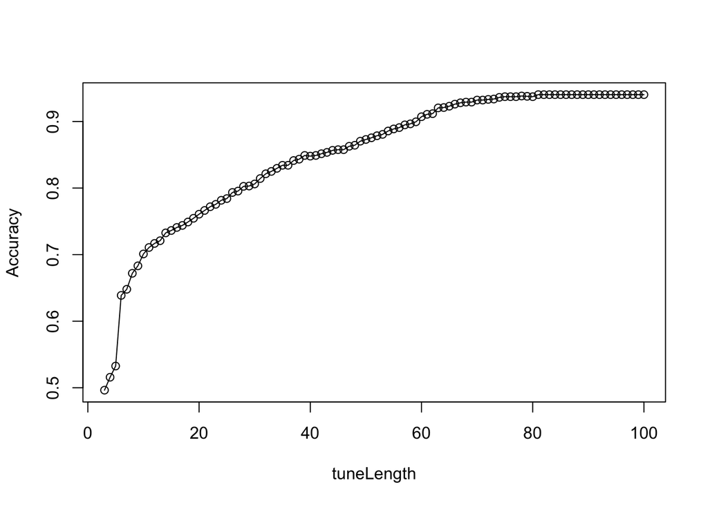

```r
ctrl <- trainControl(method = "cv",
                     number = 10,
                     allowParallel = TRUE)

accuracy <- data.frame()

for (i in 3:100) {

        model.rpart <- train(classe~.,
                          data = sub.training,
                          method = "rpart",
                          trControl = ctrl,
                          tuneLength = i)

        predict.rpart <- predict(model.rpart, newdata = sub.testing)

        accuracy[i-2,1] <- i
        accuracy[i-2,2] <- confusionMatrix(sub.testing$classe, predict.rpart)$overall[1]
                }

names(accuracy) <- c("tuneLength", "Accuracy")
plot(accuracy, type = "p", pch = 21)
lines(accuracy)
```

The graph shows how the model accuracy increases with an increase in tuneLength. This reaches as assymptote at a tuneLength of 80, at which the accuracy does not rise above 94.0%. While this level of accuracy may be suitable for some applications, other models may yield improved results.

The method below uses Stochastic Gradient Boosting with no tuning and achieves an accuracy of 96%.

```r
system.time(model.gbm <- train(classe~.,
                  data = sub.training,
                  method = "gbm",
                  trControl = ctrl))
```

```
##    user  system elapsed
##  40.153   0.472 349.476
```

```r
predict.gbm <- predict(model.gbm, newdata = sub.testing)

confusionMatrix(sub.testing$classe, predict.gbm)
```

```
## Confusion Matrix and Statistics
##
##           Reference
## Prediction   A   B   C   D   E
##          A 549   5   4   0   0
##          B  10 363   6   0   0
##          C   0   5 330   7   0
##          D   1   2  15 302   1
##          E   2   2   1   3 352
##
## Overall Statistics
##
##                Accuracy : 0.9673
##                  95% CI : (0.9585, 0.9748)
##     No Information Rate : 0.2867
##     P-Value [Acc > NIR] : < 2e-16
##
##                   Kappa : 0.9587
##
##  Mcnemar's Test P-Value : 0.06085
##
## Statistics by Class:
##
##                      Class: A Class: B Class: C Class: D Class: E
## Sensitivity            0.9769   0.9629   0.9270   0.9679   0.9972
## Specificity            0.9936   0.9899   0.9925   0.9885   0.9950
## Pos Pred Value         0.9839   0.9578   0.9649   0.9408   0.9778
## Neg Pred Value         0.9907   0.9911   0.9839   0.9939   0.9994
## Prevalence             0.2867   0.1923   0.1816   0.1592   0.1801
## Detection Rate         0.2801   0.1852   0.1684   0.1541   0.1796
## Detection Prevalence   0.2847   0.1934   0.1745   0.1638   0.1837
## Balanced Accuracy      0.9852   0.9764   0.9597   0.9782   0.9961
```

The method below uses a Random Forest method with no tuning and achieves an accuracy of 99%.

```r
system.time(model.rf <- train(classe~.,
                  data = sub.training,
                  method = "rf",
                  trControl = ctrl))
```

```
##     user   system  elapsed
##   84.195    1.899 1181.778
```

```r
predict.rf <- predict(model.rf, newdata = sub.testing)

confusionMatrix(sub.testing$classe, predict.rf)
```

```
## Confusion Matrix and Statistics
##
##           Reference
## Prediction   A   B   C   D   E
##          A 558   0   0   0   0
##          B   2 376   1   0   0
##          C   0   0 341   1   0
##          D   0   0   3 318   0
##          E   0   0   0   0 360
##
## Overall Statistics
##
##                Accuracy : 0.9964
##                  95% CI : (0.9927, 0.9986)
##     No Information Rate : 0.2857
##     P-Value [Acc > NIR] : < 2.2e-16
##
##                   Kappa : 0.9955
##
##  Mcnemar's Test P-Value : NA
##
## Statistics by Class:
##
##                      Class: A Class: B Class: C Class: D Class: E
## Sensitivity            0.9964   1.0000   0.9884   0.9969   1.0000
## Specificity            1.0000   0.9981   0.9994   0.9982   1.0000
## Pos Pred Value         1.0000   0.9921   0.9971   0.9907   1.0000
## Neg Pred Value         0.9986   1.0000   0.9975   0.9994   1.0000
## Prevalence             0.2857   0.1918   0.1760   0.1628   0.1837
## Detection Rate         0.2847   0.1918   0.1740   0.1622   0.1837
## Detection Prevalence   0.2847   0.1934   0.1745   0.1638   0.1837
## Balanced Accuracy      0.9982   0.9991   0.9939   0.9975   1.0000
```

```r
stopCluster(cores)
registerDoSEQ()
```

```r
actual <- c("B","A","B","A","A","E","D","B","A","A","B","C","B","A","E","E","A",
            "B","B","B")
rpart <- predict(model.rpart, testing)
gbm <- predict(model.gbm, testing)
rf <- predict(model.rf, testing)

case <- seq(1,20)

comparison <- cbind(case, actual, rpart, gbm, rf)

for (i in 1:20) {
        for(j in 3:5) {

                if(comparison[i,j] == "1") {
                        comparison[i,j] <- "A"
                }
                if(comparison[i,j] == "2") {
                        comparison[i,j] <- "B"
                }
                if(comparison[i,j] == "3") {
                        comparison[i,j] <- "C"
                }
                if(comparison[i,j] == "4") {
                        comparison[i,j] <- "D"
                }
                if(comparison[i,j] == "5") {
                        comparison[i,j] <- "E"
                }
        }
}


comparison
```

```
##       case actual rpart gbm rf
##  [1,] "1"  "B"    "B"   "B" "B"
##  [2,] "2"  "A"    "A"   "A" "A"
##  [3,] "3"  "B"    "C"   "B" "B"
##  [4,] "4"  "A"    "D"   "A" "A"
##  [5,] "5"  "A"    "A"   "A" "A"
##  [6,] "6"  "E"    "E"   "E" "E"
##  [7,] "7"  "D"    "D"   "D" "D"
##  [8,] "8"  "B"    "C"   "B" "B"
##  [9,] "9"  "A"    "A"   "A" "A"
## [10,] "10" "A"    "A"   "A" "A"
## [11,] "11" "B"    "B"   "B" "B"
## [12,] "12" "C"    "C"   "C" "C"
## [13,] "13" "B"    "B"   "B" "B"
## [14,] "14" "A"    "A"   "A" "A"
## [15,] "15" "E"    "E"   "E" "E"
## [16,] "16" "E"    "E"   "E" "E"
## [17,] "17" "A"    "A"   "A" "A"
## [18,] "18" "B"    "B"   "B" "B"
## [19,] "19" "B"    "B"   "B" "B"
## [20,] "20" "B"    "B"   "B" "B"
```

# Out of Sample Error

For the chosen method, the out of sample error is:

```r
OSA <-1 - confusionMatrix(sub.testing$classe, predict.gbm)$overall[1]

OSA
```

```
##   Accuracy
## 0.03265306
```